# R-tarea.R

```r
## Realmente, las observaciones de cada variables corresponde a 104 semanas.
## Sin embargo como juntamos los datos nos sale 312 observaciones diferentes.
## Segun solamente mirando a los graficos no se ve bien
## si existe una relacion entre los variables radio, stout y tv.
```

11. La columna in_store mide el stock disponible que hay en las tiendas para vender el producto, de manera indexada. Crea un gráfico de dispersión con ggplot que compare new_vol_sales frente a in_store. Presta atención a qué columna pondrás en el eje 𝑥 y cuál en el 𝑦: para ello, ten en cuenta que new_vol_sales será la variable objetivo del modelo, i.e., el analista explicar esa variable en función de las demás. Además, añade una capa con geom_smooth(): los ejes 𝑥 e 𝑦 serán los mismos que pongas en el geom del gráfico de dispersión. Comenta qué conclusiones sacas a la vista del gráfico (piensa en qué relación hay entre el stock y las ventas).

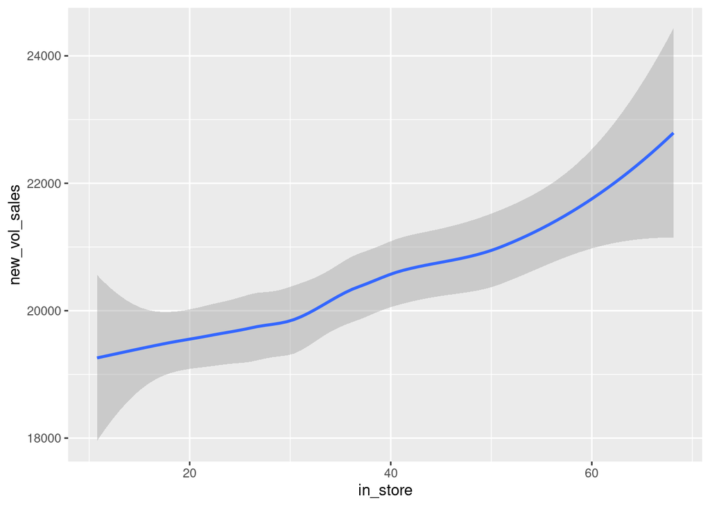

```r
df_mmm %>%
  ggplot(aes(x = in_store , y = new_vol_sales)) +
  geom_smooth()
```

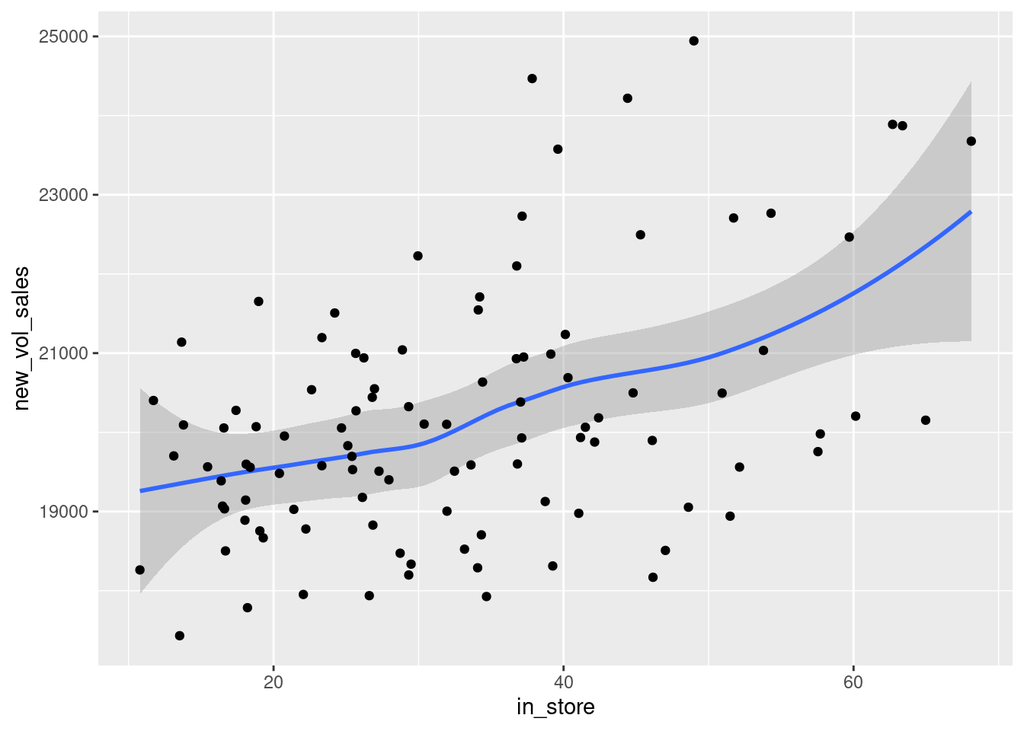

```r
##Como se explicó en ejercicio 1 y deberia ser new_vol_sales y in_store deberia
##ser in x axis por in_store es variable independiente y new_vol_sales depende de eso.
##geom_smooth nos da una idea de prediccion sobre relacion entre los variables.
##Pero es un fitted- line. Podemos comparar con scatterplot de mismo variables.
##Podemos decir in_store y new_vol_sales tiene relacion positiva respecto a smooth_line.



df_mmm %>%
  ggplot(aes(x = in_store , y = new_vol_sales)) +
  geom_smooth() +
  geom_point()
```

12. Repite el gráfico anterior pero de dos formas diferentes (no pongas geom_smooth esta vez). • Colorea cada punto en función de la columna newspaper_inserts. Te recomiendo que uses as.factor() con esa columna en el gráfico. • Colorea cada punto de manera diferente en función de la columna tv.

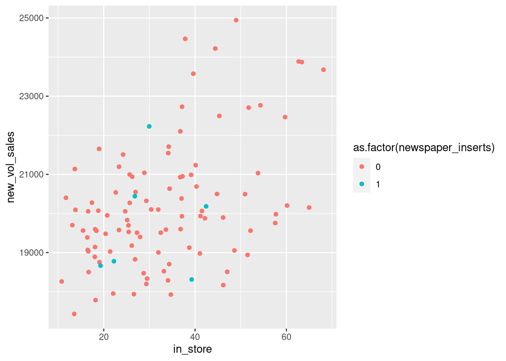

```r
df_mmm %>%
  ggplot(aes(
    x = in_store ,
    y = new_vol_sales,
    colour = as.factor(newspaper_inserts)
  )) +
  geom_point()
```

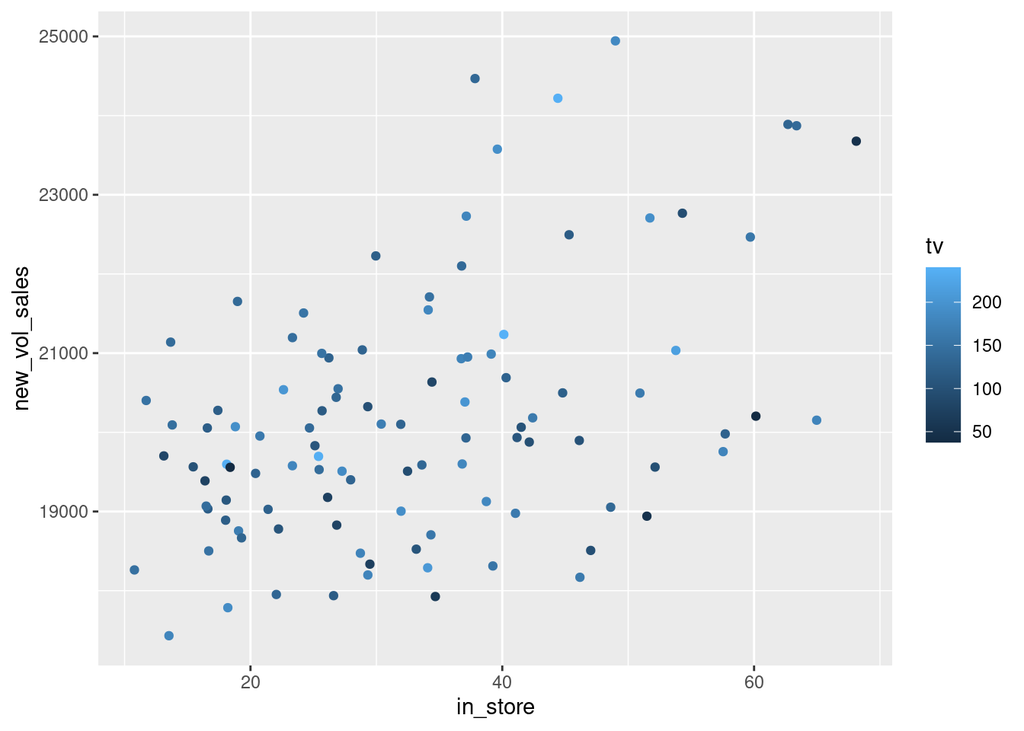

```r
df_mmm %>%
  ggplot(aes(x = in_store , y = new_vol_sales, colour = tv)) +
  geom_point()
```

13. Crea otra columna indicando si se ha aplicado descuento o no (es decr, si la columna discount es mayor que 0 o no). Puedes llamarla discount_yesno, por ejemplo, y puede ser numérica o logical. Luego agrega el data frame calculando la media de base_price para los casos en los que hay descuento y los casos en los que no. O sea, el resultado será un data frame de dos filas y dos columnas. Usa este data frame para crear un gráfico de columnas. Observación. Valoraré positivamente que no crees nuevos data frames (tampoco sobreescribas el origina porque lo necesitarás más adelante), sino que encadenes todas las operaciones con el operador pipe %>%, incluido el gráfico de ggplot.

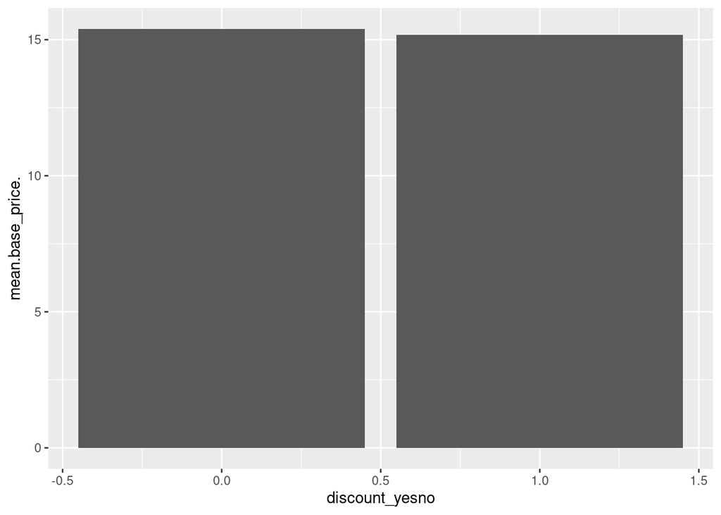

```r
df_mmm %>%
  mutate(discount_yesno = ifelse(discount > 0, 1, 0)) %>%
  group_by(discount_yesno) %>%
  summarise(mean(base_price)) %>%
  data.frame() %>%
  ggplot +
  geom_bar(aes(x = discount_yesno, y = mean.base_price.), stat = "identity")
```

14. Apóyate en el siguiente código para crear una función que ajuste un modelo de regresión en los datos. La función recibirá como entrada un vector character con las variables que se quieran usar como explicativas en el modelo. Con ese vector, dentro de la función crea un nuevo data frame que tenga esas variables y la variable explicativa, new_vol_sales. Este data frame lo usarás para ajustar el modelo siguiendo el código siguiente. Ese código calcula lo que se llama R cuadrado ajustado, una métrica qué indica cómo de bueno es el modelo: cuanto más alto, menor error hay. Finalmente, llama a la función usando como vector de entrada c(“tv”, “radio”), es decir, ajustarás un modelo que intente explicar las ventas en función de la publicidad realizada en televisión y en radio. Observación. Lo que en el código se llama df_aux hace referencia al data frame auxiliar que crearás dentro de la función.

```r
calcular_r_cuadrado_ajustado <- function(variables_explicativas) {
  df_variables_explicativas <-
    data.frame(df_mmm['new_vol_sales'], df_mmm[variables_explicativas])

  # This code fits a linear regression model with all the variables
  # in df_aux, using new_vol_sales as target variable
  my_model <-
    lm(new_vol_sales ~ ., data = df_variables_explicativas)

  # Value to be returned by the function, the adjusted R squared.
  return (summary(my_model)$adj.r.squared)
}

calcular_r_cuadrado_ajustado(c("tv", "radio"))
```

```
## [1] 0.01025529
```

15. Debajo tienes tres vectores con nombres de variables. Crea una lista con esos vectores, es decir, una lista de tres elementos (cada elemento será cada uno de los vectores). Ahora usa map_dbl() o sapply() para llamar a tu función para cada uno de los vectores. El resultado de tu código será un vector de tres números: cada número será el R cuadradado ajustado de los modelos que se ajustan con esos conjuntos de variables. ¿Qué modelo es el mejor, de acuerdo al R cuadrado ajustado? • c(“base_price”, “radio”, “tv”, “stout”) • c(“base_price”, “in_store”, “discount”, “radio”, “tv”, “stout”) • c(“in_store”, “discount”)

```r
v1 <- c("base_price", "radio", "tv", "stout")
v2 <- c("base_price", "in_store", "discount", "radio", "tv", "stout")
v3 <- c("in_store", "discount")

my_list <- list(v1, v2, v3)
map_dbl(my_list, calcular_r_cuadrado_ajustado)
```

```
## [1] 0.6906219 0.7836765 0.2033219
```

```r
##Resultado enseña que mejor model segun criteria de adjusted R squared es model 2.
##Porque explica mas porcentage de variacion en new_vol_sales
```